# Case study: Cyclistic How to tranform the casual riders to manual riders

## Part 1: Ask

1. Business task statement As a junior data analyst at Cyclistic, my task is to analyze how annual members and casual riders use Cyclistic bikes differently. The goal is to uncover behavioral patterns and trends in ride length, frequency, day-of-week usage, and other relevant variables. These insights will support the marketing team in designing targeted strategies to convert more casual riders into annual members and thus increase long-term revenue for the company.
2. My stakeholders:
- Lily Moreno - Director of Marketing – needs insights to guide the new marketing campaign
- Marketing Analytics Team - Will use your analysis to measure performance and impact of the campaign
- Cyclistic Executive Team - Final decision-makers who must approve any proposed strategy
3. The business context There are over 5800 bikes have been shared and over 692 docking stations. The users are devided two type: Annual members and casual riders (single/day-pass users). Depening on their purposes, but the large scale in their users uses bike for their daily traveling to work. There are 4 types of bike: Standard bikes, e-bikes, hand tricycles, cargo bikes (8% use assistive options)
4. The business questions
- “How do annual members and casual riders use Cyclistic bikes differently?”
- Why would casual riders choose to become members?
- How can digital media be used to influence their decision?

## Part 2: Prepare and process dataset

1. Loading dataset The dataset is located in “Cloud/project/dataset” on the Positcloud website. Let’s see what the data is organized:

```r
install.packages('tidyverse')
library(tidyverse)
install.packages('readr') #when install tidyverse was failed, cannot install completely readr
library(readr)

# inport data
divvy_2019_q1 <- read_csv('dataset/Divvy_2019_Q1.csv')
divvy_2020_q1 <- read_csv('dataset/Divvy_2020_Q1.csv')
```

2. Exploring the dataset The dataset is ROCCC:
- Reliable: cannot judge because it is hypothetical data
- Original: yes.
- Comprehensive: yes
- Current: yes, the dataset was setting for the questions in the 2020 context.
- Cited: yes. Because these are the datasets was provided in my Course, so I don’t have any problems with the authority or privacy. And I also recheck them. The data have any error or how about the dataset’s integrity?

```r
install.packages('skimr')
```

```r
library(skimr)
divvy_2019_q1 %>%
skim_without_charts()
```

Data summary

| Name | Piped data |
| --- | --- |
| Number of rows | 365069 |
| Number of columns | 12 |
| _______________________ |  |
| Column type frequency: |  |
| character | 4 |
| numeric | 6 |
| POSIXct | 2 |
| ________________________ |  |
| Group variables | None |

**Variable type: character**

| skim_variable | n_missing | complete_rate | min | max | empty | n_unique | whitespace |
| --- | --- | --- | --- | --- | --- | --- | --- |
| from_station_name | 0 | 1.00 | 10 | 43 | 0 | 594 | 0 |
| to_station_name | 0 | 1.00 | 10 | 43 | 0 | 600 | 0 |
| usertype | 0 | 1.00 | 8 | 10 | 0 | 2 | 0 |
| gender | 19711 | 0.95 | 4 | 6 | 0 | 2 | 0 |

**Variable type: numeric**

| skim_variable | n_missing | complete_rate | mean | sd | p0 | p25 | p50 | p75 | p100 |
| --- | --- | --- | --- | --- | --- | --- | --- | --- | --- |
| trip_id | 0 | 1.00 | 21960871.66 | 127175.00 | 21742443 | 21848765 | 21961829 | 22071823 | 22178528 |
| bikeid | 0 | 1.00 | 3429.48 | 1923.32 | 1 | 1777 | 3489 | 5157 | 6471 |
| tripduration | 0 | 1.00 | 1016.34 | 27913.51 | 61 | 326 | 524 | 866 | 10628400 |
| from_station_id | 0 | 1.00 | 198.09 | 153.49 | 2 | 76 | 170 | 287 | 665 |
| to_station_id | 0 | 1.00 | 198.58 | 154.47 | 2 | 76 | 168 | 287 | 665 |
| birthyear | 18023 | 0.95 | 1981.67 | 11.25 | 1900 | 1975 | 1985 | 1990 | 2003 |

**Variable type: POSIXct**

| skim_variable | n_missing | complete_rate | min | max | median | n_unique |
| --- | --- | --- | --- | --- | --- | --- |
| start_time | 0 | 1 | 2019-01-01 00:04:37 | 2019-03-31 23:53:48 | 2019-02-25 07:52:56 | 343022 |
| end_time | 0 | 1 | 2019-01-01 00:11:07 | 2019-06-17 16:04:35 | 2019-02-25 08:03:50 | 338367 |

Dataset of quater 1 in 2019: 12 columns and 365069 rows => the gender has 19711 missing values and birthyear has 18023 missing value. So, I decide to assign “Unknown” for the missing value.

```r
divvy_2019_q1$gender <- ifelse(is.na(divvy_2019_q1$gender), "Unknown", divvy_2019_q1$gender)
divvy_2019_q1$birthyear <- ifelse(is.na(divvy_2019_q1$birthyear), "Unknown", divvy_2019_q1$birthyear)
```

```r
table(divvy_2019_q1$usertype)
```

```
##
##   Customer Subscriber
##      23163     341906
```

```r
prop.table(table(divvy_2019_q1$usertype))
```

```
##
##   Customer Subscriber
## 0.06344828 0.93655172
```

ALmost the data in divvy_2019_q1 is about subcriber, if what I think is true, this dataset is almost about the manual user and just have small part user have not yet subcribed membership (6.34%). So, in the some sides, the rate tranformation users (new user to subriber) is high.

```r
table(divvy_2019_q1$gender)
```

```
##
##  Female    Male Unknown
##   66918  278440   19711
```

```r
prop.table(table(divvy_2019_q1$gender))
```

```
##
##     Female       Male    Unknown
## 0.18330233 0.76270513 0.05399253
```

What wrong with female, their husband or boyfriend ride the bike? Or they prefer other type vehicles?

```r
divvy_2020_q1 %>%
  skim_without_charts()
```

Data summary

| Name | Piped data |
| --- | --- |
| Number of rows | 426887 |
| Number of columns | 13 |
| _______________________ |  |
| Column type frequency: |  |
| character | 5 |
| numeric | 6 |
| POSIXct | 2 |
| ________________________ |  |
| Group variables | None |

**Variable type: character**

| skim_variable | n_missing | complete_rate | min | max | empty | n_unique | whitespace |
| --- | --- | --- | --- | --- | --- | --- | --- |
| ride_id | 0 | 1 | 16 | 16 | 0 | 426887 | 0 |
| rideable_type | 0 | 1 | 11 | 11 | 0 | 1 | 0 |
| start_station_name | 0 | 1 | 5 | 43 | 0 | 607 | 0 |
| end_station_name | 1 | 1 | 5 | 43 | 0 | 602 | 0 |
| member_casual | 0 | 1 | 6 | 6 | 0 | 2 | 0 |

**Variable type: numeric**

| skim_variable | n_missing | complete_rate | mean | sd | p0 | p25 | p50 | p75 | p100 |
| --- | --- | --- | --- | --- | --- | --- | --- | --- | --- |
| start_station_id | 0 | 1 | 209.80 | 163.22 | 2.00 | 77.00 | 176.00 | 298.00 | 675.00 |
| end_station_id | 1 | 1 | 209.34 | 163.20 | 2.00 | 77.00 | 175.00 | 297.00 | 675.00 |
| start_lat | 0 | 1 | 41.90 | 0.04 | 41.74 | 41.88 | 41.89 | 41.92 | 42.06 |
| start_lng | 0 | 1 | -87.64 | 0.02 | -87.77 | -87.66 | -87.64 | -87.63 | -87.55 |
| end_lat | 1 | 1 | 41.90 | 0.04 | 41.74 | 41.88 | 41.89 | 41.92 | 42.06 |
| end_lng | 1 | 1 | -87.64 | 0.02 | -87.77 | -87.66 | -87.64 | -87.63 | -87.55 |

**Variable type: POSIXct**

| skim_variable | n_missing | complete_rate | min | max | median | n_unique |
| --- | --- | --- | --- | --- | --- | --- |
| started_at | 0 | 1 | 2020-01-01 00:04:44 | 2020-03-31 23:51:34 | 2020-02-17 05:01:27 | 399265 |
| ended_at | 0 | 1 | 2020-01-01 00:10:54 | 2020-05-19 20:10:34 | 2020-02-17 05:48:58 | 399532 |

Divvy_2020_q1: in end_station_name, end_station_id, end_lat, end_lng columns, each of them has one missing value. I assign “Unknown” for missing value.

```r
divvy_2020_q1$end_station_name <- ifelse(is.na(divvy_2020_q1$end_station_name), "Unknown", divvy_2020_q1$end_station_name)
divvy_2020_q1$end_station_id <- ifelse(is.na(divvy_2020_q1$end_station_id), "Unknown", divvy_2020_q1$end_station_id)
divvy_2020_q1$end_lat <- ifelse(is.na(divvy_2020_q1$end_lat), "Unknown", divvy_2020_q1$end_lat)
divvy_2020_q1$end_lng <- ifelse(is.na(divvy_2020_q1$end_lng), "Unknown", divvy_2020_q1$end_lng)
```

The rate of member type and gender

```r
table(divvy_2020_q1$member_casual)
```

```
##
## casual member
##  48480 378407
```

```r
prop.table(table(divvy_2020_q1$member_casual))
```

```
##
##    casual    member
## 0.1135664 0.8864336
```

I have a hypothety that the firm change the way deviding customer: casual == customer, subcriber == member.

```r
table(divvy_2019_q1$gender)
```

```
##
##  Female    Male Unknown
##   66918  278440   19711
```

```r
prop.table(table(divvy_2019_q1$gender))
```

```
##
##     Female       Male    Unknown
## 0.18330233 0.76270513 0.05399253
```

3. Creating new columns
- What time for each trip: ride_length: the duration of each ride in minutes

```r
library(dplyr)
divvy_2019_q1 <- divvy_2019_q1 %>%
  mutate(ride_length = as.numeric(difftime(end_time, start_time, units = "mins")))
divvy_2020_q1 <- divvy_2020_q1 %>%
  mutate(ride_length = as.numeric(difftime(ended_at, started_at, units = "mins")))
```

Remove if the ride length <= 0:

```r
divvy_2019_q1 <- divvy_2019_q1 %>%
  filter(ride_length > 0)
divvy_2020_q1 <- divvy_2020_q1 %>%
  filter(ride_length >0)
```

What day on the week the trip was started?: day_of_week: the weekday when the ride started

```r
divvy_2019_q1 <- divvy_2019_q1 %>%
  mutate(day_of_week = weekdays(as.Date(start_time)))
divvy_2020_q1 <- divvy_2020_q1 %>%
  mutate(day_of_week = weekdays(as.Date(started_at)))
```

4. Analyzing dataset
- Calculating the statistic of each member type. **divvy_2019_q1**

```r
divvy_2019_q1 %>%
  group_by(usertype) %>%
  summarise(
    mean_ride = mean(ride_length, na.rm = T),
    median_ride = median(ride_length, na.rm = T),
    max_ride = max(ride_length, na.rm =T),
    min_ride = min(ride_length, na.rm = T)
  )
```

| usertype | mean_ride | median_ride | max_ride | min_ride |
| --- | --- | --- | --- | --- |
| Customer | 61.94193 | 23.35 | 177200.4 | 1.016667 |
| Subscriber | 13.89287 | 8.35 | 101607.1 | 1.016667 |

**divvy_2020_q1**

```r
divvy_2020_q1 %>%
  group_by(member_casual) %>%
  summarise(
    mean_ride = mean(ride_length, na.rm = T),
    median_ride = median(ride_length, na.rm = T),
    max_ride = max(ride_length, na.rm =T),
    min_ride = min(ride_length, na.rm = T)
  )
```

| member_casual | mean_ride | median_ride | max_ride | min_ride |
| --- | --- | --- | --- | --- |
| casual | 96.20008 | 21.283333 | 156450.40 | 0.01666667 |
| member | 12.67711 | 8.583333 | 93793.52 | 0.01666667 |

###Calculating the number of trips for each weekday. **divvy_2019_q1**

```r
trip_2019 <- divvy_2019_q1 %>%
  group_by(day_of_week, usertype) %>%
  summarise(num_trip_of_weekday = n(),
            mean_time_trip = mean(ride_length, na.rm = T)) %>%
  arrange(day_of_week, usertype)
trip_2019
```

| day_of_week | usertype | num_trip_of_weekday | mean_time_trip |
| --- | --- | --- | --- |
| Friday | Customer | 3375 | 59.89280 |
| Friday | Subscriber | 59672 | 13.88976 |
| Monday | Customer | 1892 | 44.45613 |
| Monday | Subscriber | 48507 | 14.63459 |
| Saturday | Customer | 5993 | 60.32985 |
| Saturday | Subscriber | 29309 | 16.98921 |
| Sunday | Customer | 3766 | 41.58239 |
| Sunday | Subscriber | 24233 | 16.79934 |
| Thursday | Customer | 2920 | 133.79221 |
| Thursday | Subscriber | 63983 | 12.00980 |

[output cut: 4 more lines]

**divvy_2020_q1**

```r
trip_2020 <- divvy_2020_q1 %>%
  group_by(day_of_week, member_casual) %>%
  summarise(num_trip_of_weekday = n(),
            mean_time_trip = mean(ride_length, na.rm = T)) %>%
  arrange(day_of_week, member_casual)
trip_2020
```

| day_of_week | member_casual | num_trip_of_weekday | mean_time_trip |
| --- | --- | --- | --- |
| Friday | casual | 5133 | 119.09372 |
| Friday | member | 55496 | 12.62207 |
| Monday | casual | 4802 | 74.71312 |
| Monday | member | 61923 | 12.97714 |
| Saturday | casual | 7480 | 100.28593 |
| Saturday | member | 30104 | 15.49982 |
| Sunday | casual | 14886 | 95.17611 |
| Sunday | member | 35964 | 15.82234 |
| Thursday | casual | 4851 | 127.00249 |
| Thursday | member | 61245 | 11.55388 |

[output cut: 4 more lines]

## Part 4: Share - Creating Viz

Viz show the relationships between weekdays and the number of trips in 2019

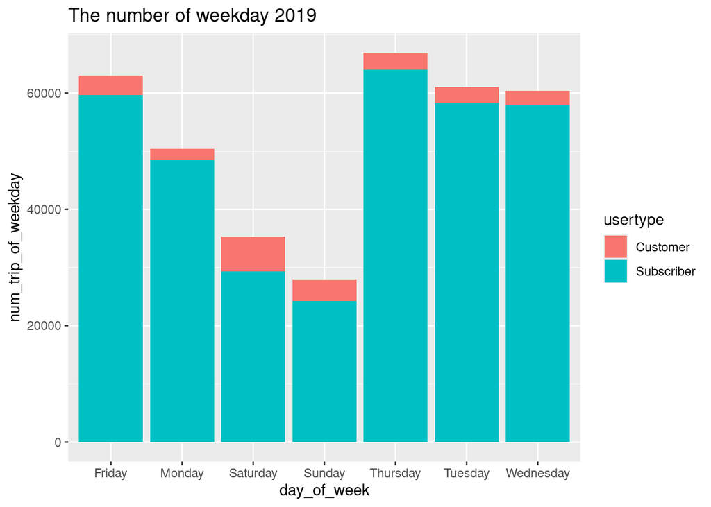

```r
library(ggplot2)
ggplot(trip_2019, aes(x = day_of_week, y = num_trip_of_weekday, fill = usertype)) +
  geom_col() +
  labs(title = "The number of weekday 2019")
```

The Viz show the relationship between weekdays and the trip time

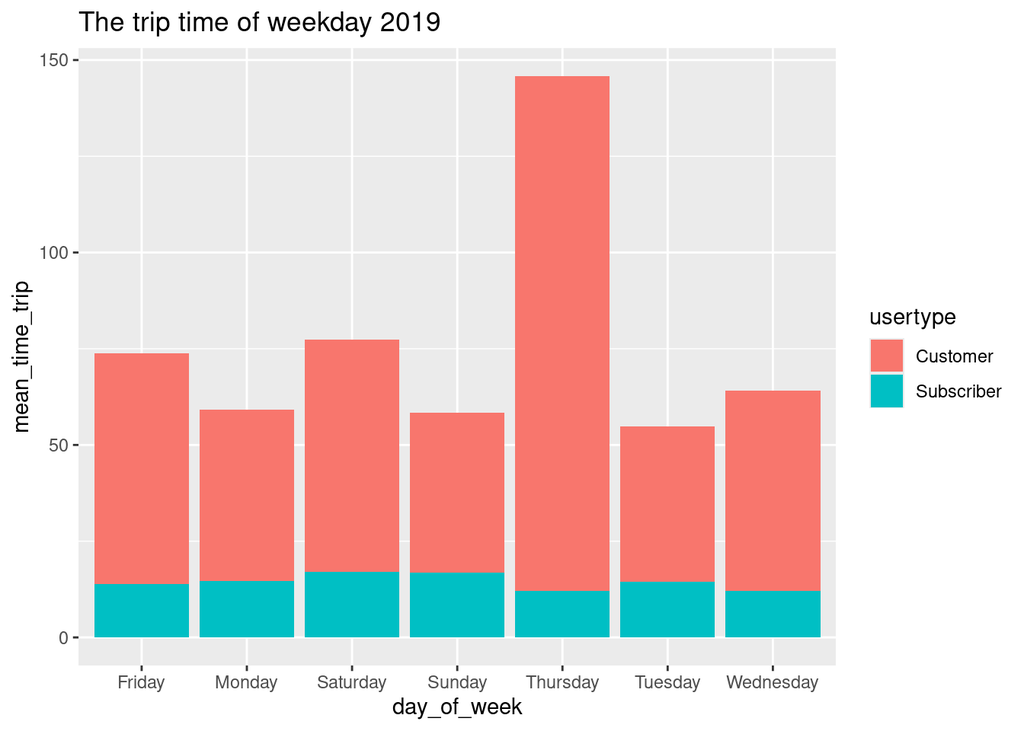

```r
library(ggplot2)
ggplot(trip_2019, aes(x = day_of_week, y = mean_time_trip, fill = usertype)) +
  geom_col() +
  labs(title = "The trip time of weekday 2019")
```

We can see that the trips during the week are all by the subscriber group, they are the majority, only on weekends do they use a lot, and there is a sudden increase compared to weekdays. In terms of usage time, customers are clearly higher than subscribers.

### The relationship between weekdays and others in 2020

- Weekdays vs number of trip

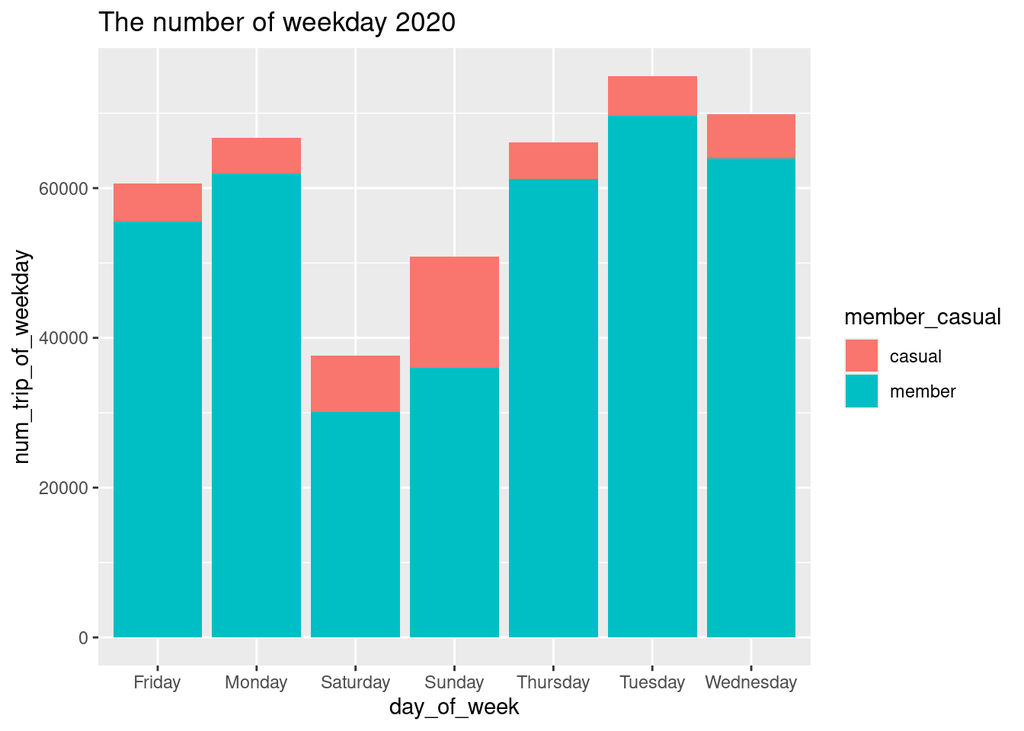

```r
library(ggplot2)
ggplot(trip_2020, aes(x = day_of_week, y = num_trip_of_weekday, fill = member_casual)) +
  geom_col() +
  labs(title = "The number of weekday 2020")
```

- Weekdays vs trip time

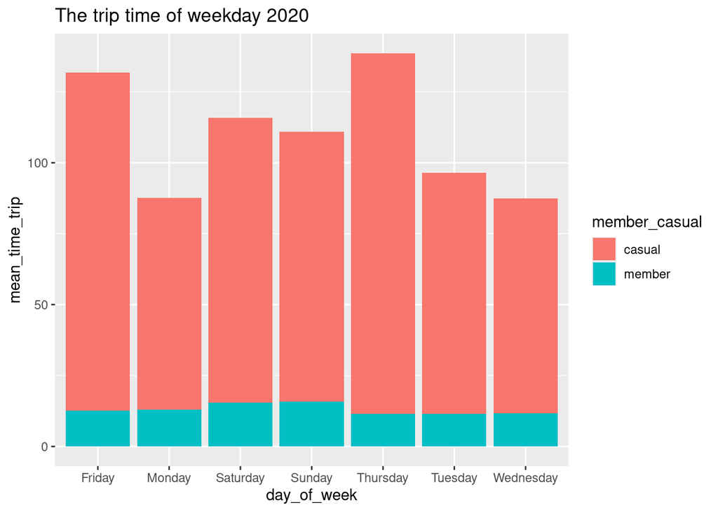

```r
library(ggplot2)
ggplot(trip_2020, aes(x = day_of_week, y = mean_time_trip, fill = member_casual)) +
  geom_col() +
  labs(title = "The trip time of weekday 2020")
```

*Similar to 2019, in 2020 the data still tells the same story, the number of uses of the member group is mainly during the week, and on weekends there is a clear increase from casual people.* In terms of distance traveled, casual people travel longer, longer than members (move quickly, at a time). => the casual group tends to relax and entertain. The member group tends to go to work, move quickly.

### The starting time

Creating the new column dimentrating the starting time in each day of user.

```r
library(lubridate)
divvy_2019_q1 <- divvy_2019_q1 %>%
  mutate(start_hour = hour(start_time))
divvy_2020_q1 <- divvy_2020_q1 %>%
  mutate(start_hour = hour(started_at))
```

What the relationship of the start time in day with type of user? * 2019:

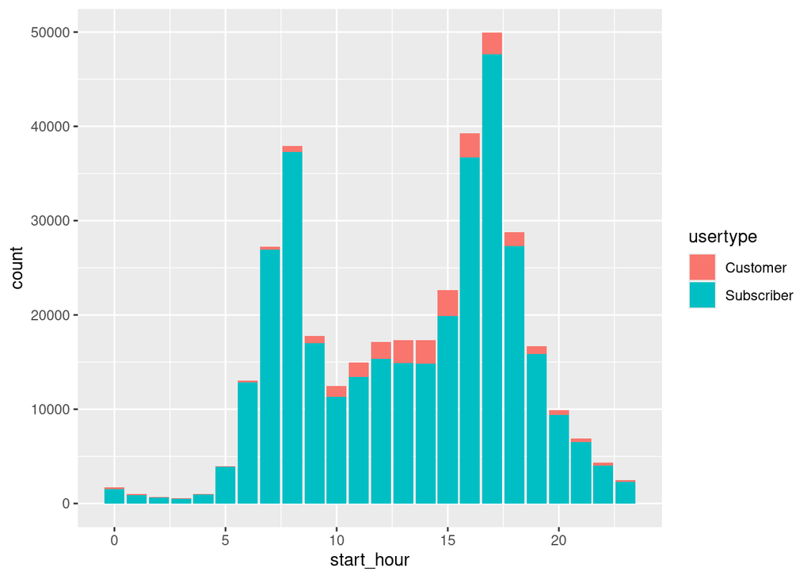

```r
ggplot(divvy_2019_q1, aes( x = start_hour, fill = usertype)) +
  geom_bar()
```

- 2020:

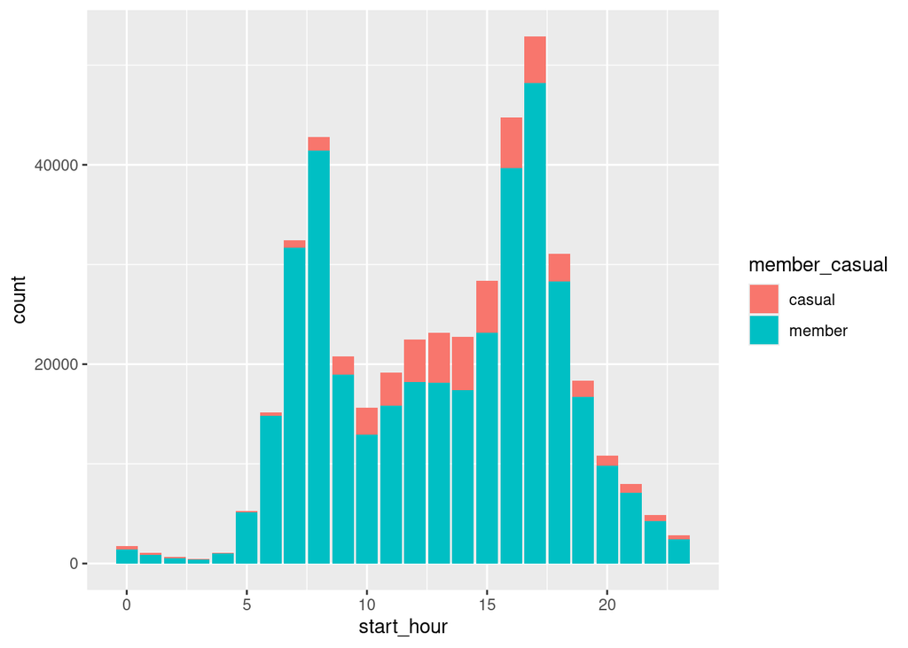

```r
ggplot(divvy_2020_q1, aes( x = start_hour, fill = member_casual)) +
  geom_bar()
```

In the both graph, the same trends that casual (customer -2019) use the firm service in the 10-16h. The member (subcriber - 2019) user service in the time to going work almost